# Netzwerkanalyse mit `tidygraph`

## Merging

Besides, all the joins are supported as well. If you want to add edge data, they need to contain `from` and `to` columns which refer to valid nodes.

There are also `bind_*()` functions which are graph-specific: `bind_nodes()`, `bind_edges()`, and `bind_graphs()`. The latter does not allow you to create edges between the different graphs, they rather become singular components in the same graph. If you want to merge them – as they share nodes – `graph_join()` is the way to go. It works like a full join hence keeps the individual edges from both graphs. Node names need to be provided and will be used for joining.

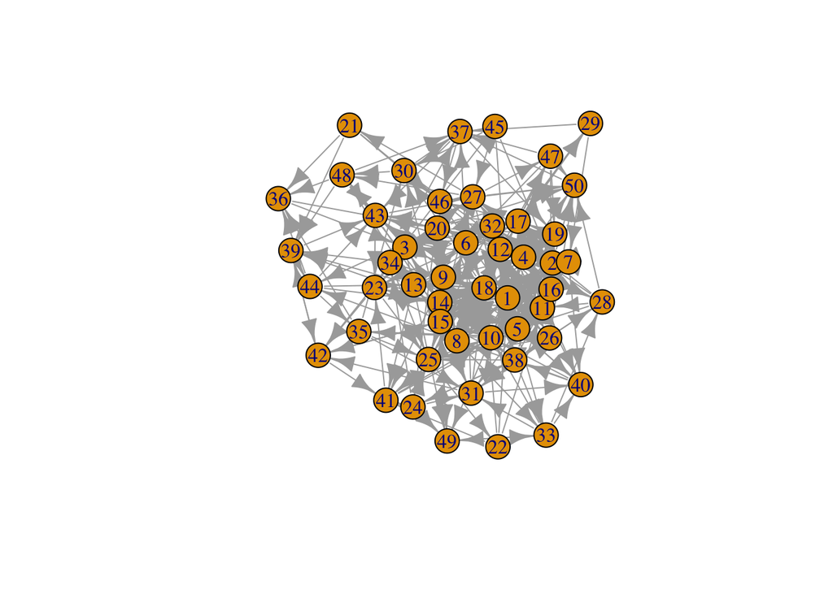

```r
graph_1 <- play_erdos_renyi(20, 0.2, directed = TRUE) %>%
  mutate(name = 1:20) # after creating a new graph, nodes are active by default
graph_2 <- play_erdos_renyi(50, 0.1, directed = TRUE) %>%
  mutate(name = 1:50)

plot(graph_join(graph_1, graph_2))
```

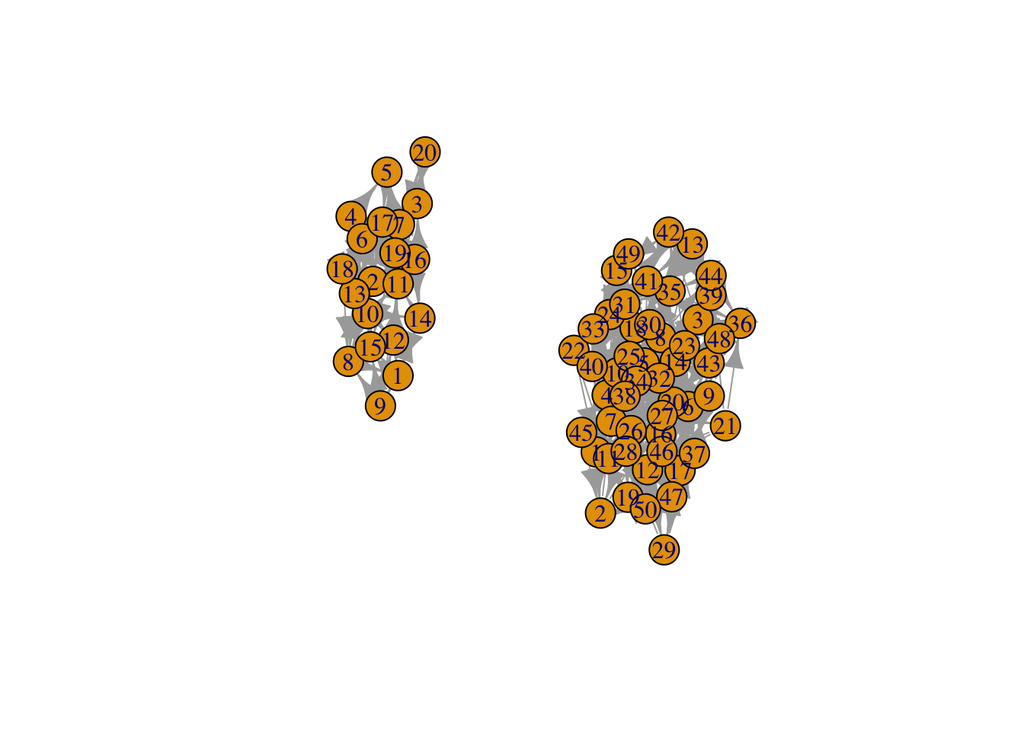

```r
plot(bind_graphs(graph_1, graph_2))
```

## `reroute()`

This function changes beginning and end nodes of edges. It has an `subset =` argument as well.

```r
# reverse edges
graph_1 %E>%
  reroute(from = to, to = from)
```

```
## # A tbl_graph: 20 nodes and 73 edges
## #
## # A directed simple graph with 1 component
## #
## # Edge Data: 73 x 2 (active)
##    from    to
##   <int> <int>
## 1     1     8
## 2     1     9
## 3     1    12
## 4     1    14
## 5     2    10
## 6     2    11
## # … with 67 more rows
## #
## # Node Data: 20 x 1
##    name
##   <int>
## 1     1
## 2     2
## 3     3
## # … with 17 more rows
```

```r
# demonstrate subset
play_erdos_renyi(50, 0.5) %E>%
  reroute(from = 1:10, subset = to == 2)
```

```
## # A tbl_graph: 50 nodes and 1200 edges
## #
## # A directed multigraph with 1 component
## #
## # Edge Data: 1,200 x 2 (active)
##    from    to
##   <int> <int>
## 1     1    50
## 2     2     1
## 3     5     1
## 4     6     1
## 5     7     1
## 6     8     1
## # … with 1,194 more rows
## #
## # Node Data: 50 x 0
```

# `morph()` and `unmorph()`

Sometimes, you do not only want to make minor changes like the ones demonstrated in the former sections. This is where the `morph()` function comes in handy. It provides you with a couple of functions on how to split it. `unmorph()` returns to the entire graph plus the manipulations you have made.

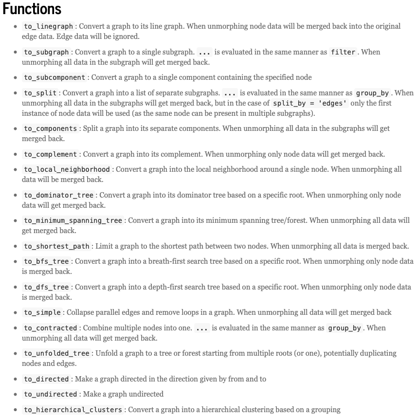

Functions for `morph()`

Functions for `morph()`: https://tidygraph.data-imaginist.com/reference/morphers.html

So, let’s check out some examples:

- `to_shortest-path()`

```r
from <- 4
to <- 3
play_erdos_renyi(50, 0.5) %N>%
  mutate(name = 1:50) %>%
  morph(to_shortest_path, from = from, to = to, mode = "out")
```

```
## # A tbl_graph temporarily morphed to a shortest path representation
## #
## # Original graph is a directed simple graph with 1 component
## # consisting of 50 nodes and 1291 edges
```

- `to_simple`

```r
edges <- tibble(
  from = c(1, 1:10),
  to = c(2, 1:10)
)
nodes <- tibble(
  name = 1:10
)

tbl_graph(nodes = nodes, edges = edges) %>%
  morph(to_simple, remove_multiples = TRUE, remove_loops = TRUE) %>%
  activate(edges) %>%
  mutate(indicator = 1) %>%
  unmorph()
```

```
## # A tbl_graph: 10 nodes and 11 edges
## #
## # A directed multigraph with 9 components
## #
## # Edge Data: 11 x 3 (active)
##    from    to indicator
##   <int> <int>     <dbl>
## 1     1     2         1
## 2     1     1        NA
## 3     2     2        NA
## 4     3     3        NA
## 5     4     4        NA
## 6     5     5        NA
## # … with 5 more rows
## #
## # Node Data: 10 x 1
##    name
##   <int>
## 1     1
## 2     2
## 3     3
## # … with 7 more rows
```

If you want to switch to your representation more permanently, use `crystallize()`. It will return a list containing the graph object(s) – this is especially handy if you split it up into sub-groups (e.g., different components which are linked together)

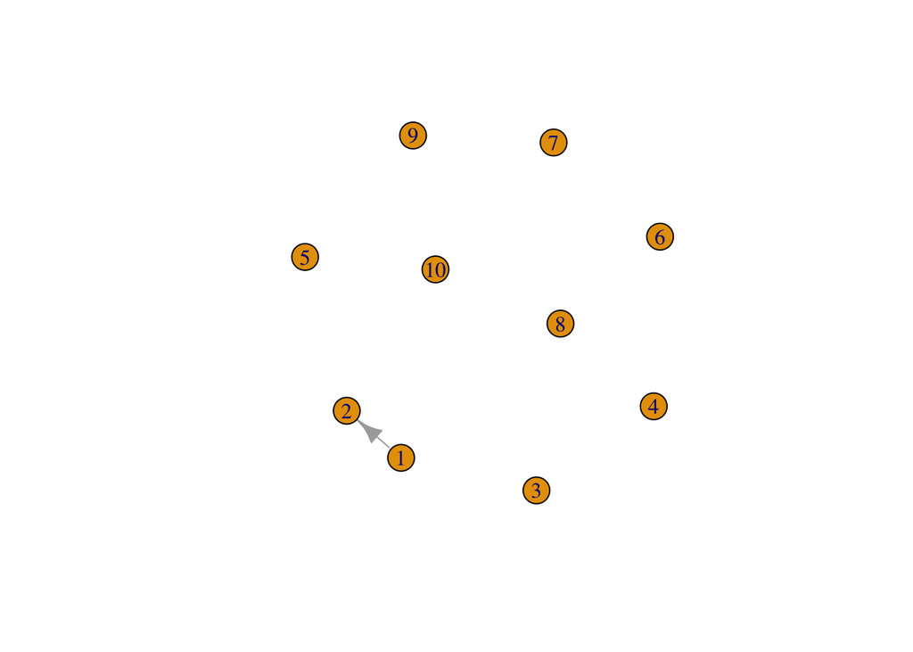

```r
edges <- tibble(
  from = c(1, 1:10),
  to = c(2, 1:10)
)
nodes <- tibble(
  name = 1:10
)

crystallize_example <- tbl_graph(nodes = nodes, edges = edges) %>%
  morph(to_simple, remove_multiples = TRUE, remove_loops = TRUE) %>%
  activate(edges) %>%
  mutate(indicator = 1) %>%
  crystallize()

plot(crystallize_example$graph[[1]])
```

Sometimes you know that your `crystallize()` call will only return one object – like in my example above. In this case, you can also use `convert()` as an abbreviation for both `morph()` and `crystallize()`.

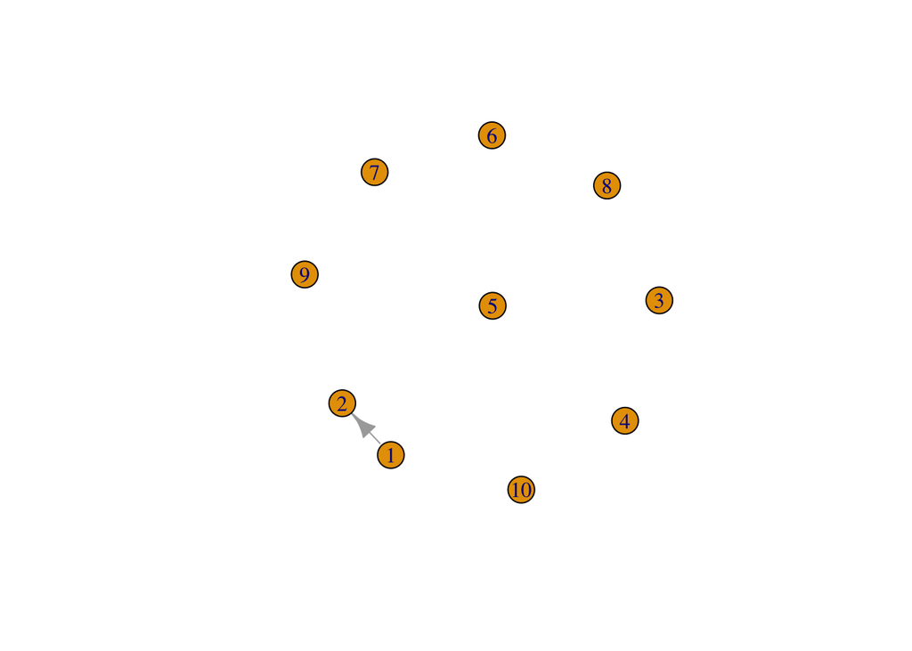

```r
convert_example <- tbl_graph(nodes = nodes, edges = edges) %>%
  convert(to_simple, remove_multiples = TRUE, remove_loops = TRUE)

plot(convert_example)
```

# Exercises

# Further links

- Find the creator’s tutorials [here](https://www.rpubs.com/Steven_Surya/tidygraph-ggraph).
- A blog post which shows [how to use `tidygraph` to derive insights from a data set on French train connections](https://rviews.rstudio.com/2019/03/06/intro-to-graph-analysis/) which was part of a *Tidy Tuesday* challenge.
- Another blog post touching upon [network analysis with R in general](https://www.jessesadler.com/post/network-analysis-with-r/) (and `tidygraph`, `igraph`, and `network` in specific)